# Telecom Customer Churn Prediction

We also decide to create a stacked model in order to create a better model. We use ctree to build model and run ctree on top of the model to allow our models to vote.

```r
#Use all models to predict train data
log_prediction_train <- predict(logit.model, type = "response", newdata = train)
log_prediction_train <- factor(ifelse(log_prediction_train >= 0.5, "Yes", "No"))


log_prediction_train_advanced <- predict(logit.model2, type = "response", newdata = train)
log_prediction_train_advanced <- factor(ifelse(log_prediction_train_advanced >= 0.5, "Yes", "No"))


decision_prediction_train <- predict(decisionTree, train)
rf_prediction_train <- predict(rf.model, newdata = train)
boost100_prediction_train <- predict(boost100, train)

svm_prediction_train <- predict(churn_classifier, train)
svm_van_prediction_train <- predict(churn_classifier_van, train)


knn59_prediction_train <- knn(train = knn_train_data, test = knn_train_data, cl = train_label, k = 59)
knn21_prediction_train <- knn(train = knn_train_data, test = knn_train_data, cl = train_label, k = 21)
```

```r
ConvertToYesNo <- function(myprediction) {
  result <- myprediction %>% as.factor()
  levels(result) <- c("No", "Yes")
  result
}
```

```r
logit.pred_churn <- ConvertToYesNo(logit.pred_churn)
logit.pred_churn2 <- ConvertToYesNo(logit.pred_churn2)
decisionTree_pred <- ConvertToYesNo(decisionTree_pred)
boost_pred100 <- ConvertToYesNo(boost_pred100)
rfpred <- ConvertToYesNo(rfpred)
churn_predictions <- ConvertToYesNo(churn_predictions)
churn_predictions_van <- ConvertToYesNo(churn_predictions_van)
test_pred_21 <- ConvertToYesNo(test_pred_21)
test_pred_59 <- ConvertToYesNo(test_pred_59)
```

```r
stacked_data = data.frame(logit.pred_churn, logit.pred_churn2, decisionTree_pred, boost_pred100, rfpred, churn_predictions, churn_predictions_van, test_pred_21, test_pred_59,test$Churn) %>% as.tbl()
```

```r
model_combined_results <- data.frame(log_prediction_train, log_prediction_train_advanced, decision_prediction_train, rf_prediction_train, boost100_prediction_train, svm_prediction_train, svm_van_prediction_train, knn59_prediction_train, knn21_prediction_train,train$Churn) %>% as.tbl()
```

```r
names(model_combined_results) <- names(stacked_data)
```

```r
library(party)
```

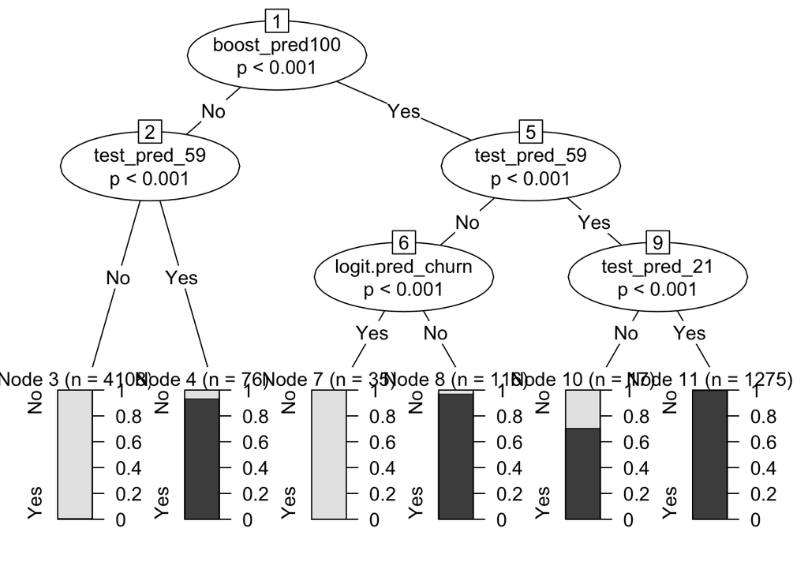

```r
#Build ctree to
stacked_model <- ctree(test.Churn ~ . , data = model_combined_results)
plot(stacked_model)
```

```r
stacked_data <- data.frame(stacked_data)
stacked_model_prediction <- predict(stacked_model, stacked_data)
confusionMatrix(as.factor(stacked_model_prediction), as.factor(stacked_data$test.Churn))
```

```
## Confusion Matrix and Statistics
##
##           Reference
## Prediction   No  Yes
##        No  1002   40
##        Yes   30  333
##
##                Accuracy : 0.9502
##                  95% CI : (0.9375, 0.961)
##     No Information Rate : 0.7345
##     P-Value [Acc > NIR] : <2e-16
##
##                   Kappa : 0.8711
##
##  Mcnemar's Test P-Value : 0.2821
##
##             Sensitivity : 0.9709
##             Specificity : 0.8928
##          Pos Pred Value : 0.9616
##          Neg Pred Value : 0.9174
##              Prevalence : 0.7345
##          Detection Rate : 0.7132
##    Detection Prevalence : 0.7416
##       Balanced Accuracy : 0.9318
##
##        'Positive' Class : No
##
```

The model plot shows that stacked ctree model uses decision tree with boosting of 100 trials as the base predictor and adjust some predictions bases on other models. We should expect the accuracy will improve from 80%. The result shows that the accuracy is 95%. But it’s still lower than KNN model.